# Assignment 5

Ted Henson

October 13, 2018

## Model 2

# Part a

```r
library(readr)
UsedCarLot <- read_csv("UsedCarLot.csv")
honda <- UsedCarLot[which(UsedCarLot$make == 'Honda'),]
accord <- honda[which(honda$model == 'Accord'),]

cardata <- accord
cardata$age <- 2018 - cardata$year

quad <- lm(price ~  I(age^2) + age, data = cardata)
summary(quad)
```

```
##
## Call:
## lm(formula = price ~ I(age^2) + age, data = cardata)
##
## Residuals:
##     Min      1Q  Median      3Q     Max
## -7.2219 -3.4068 -0.7921  2.3266 15.5286
##
## Coefficients:
##             Estimate Std. Error t value Pr(>|t|)
## (Intercept) 42.01832    1.81956  23.093  < 2e-16 ***
## I(age^2)     0.04624    0.03494   1.323    0.192
## age         -2.99169    0.60969  -4.907 1.15e-05 ***
## ---
## Signif. codes:  0 '***' 0.001 '**' 0.01 '*' 0.05 '.' 0.1 ' ' 1
##
## Residual standard error: 5.121 on 47 degrees of freedom
## Multiple R-squared:  0.8303, Adjusted R-squared:  0.8231
## F-statistic:   115 on 2 and 47 DF,  p-value: < 2.2e-16
```

```r
plot(x = cardata$age, y = cardata$price)

B0 = summary(quad)$coef[1]
B1 = summary(quad)$coef[2]
B2 = summary(quad)$coef[3]

print(paste("Price = ", B0, " + ", B1, "*age^2", " + ", B2, "*age", sep = ""))
```

```
## [1] "Price = 42.0183162034981 + 0.0462353438364535*age^2 + -2.99168930501595*age"
```

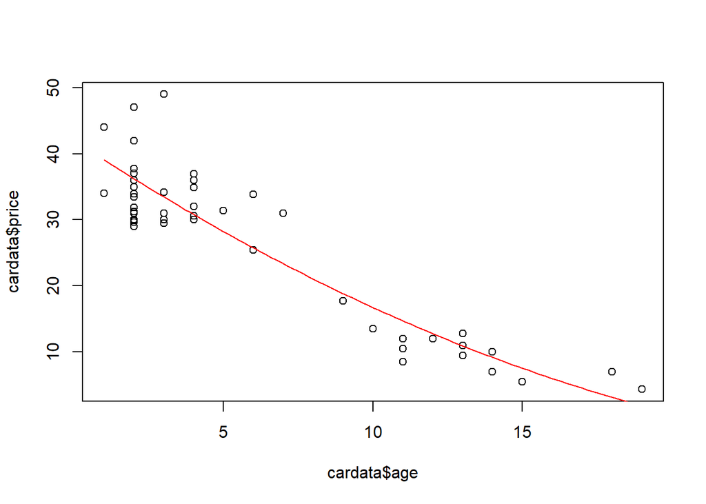

```r
curve(B0+ I(B1*x^2) + I(B2*x),add=TRUE, col="red")
```

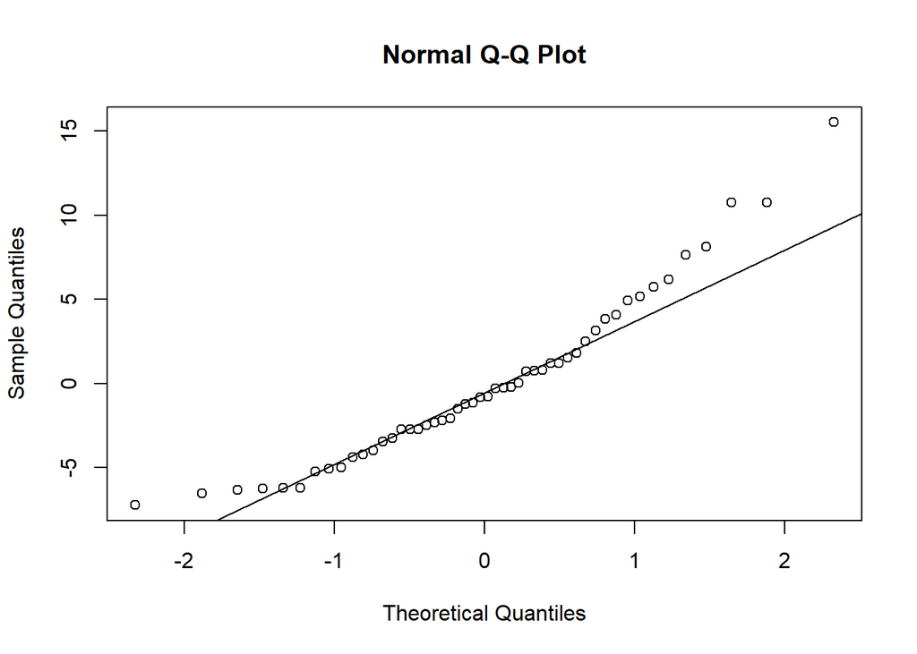

```r
qqnorm(quad$residuals)
qqline(quad$residuals)
```

# Part b

```r
cor.test(I(cardata$age^2), cardata$price)
```

```
##
##  Pearson's product-moment correlation
##
## data:  I(cardata$age^2) and cardata$price
## t = -11.791, df = 48, p-value = 8.81e-16
## alternative hypothesis: true correlation is not equal to 0
## 95 percent confidence interval:
##  -0.9197870 -0.7681755
## sample estimates:
##        cor
## -0.8621734
```

The null hypothesis is that there is no relationship between a car’s age squared + age and it’s price. The alternative hypothesis is that there is a relationship. The correlation test gives a p value way below the .05 significant threshold, so there most likely is a relationship. The correlation coefficient of -.86 shows that this relationship is strongly negative.

# Part c

```r
seven <- data.frame(age = 7)
predict.lm(quad, seven, interval = 'prediction', level = .95)
```

```
##        fit      lwr      upr
## 1 23.34202 12.73813 33.94591
```

# Part d

```r
# uniroot(function(x) B0+  B1*x^2 + B2*x, interval = c(1,100), lower = 1, upper = 100, extendInt = 'yes')
quadratic_function <- function(a, b, c){

pos_root <- ((-b) + sqrt((b^2) - 4*a*c)) / (2*a)

neg_root <- ((-b) - sqrt((b^2) - 4*a*c)) / (2*a)

print(pos_root)

print(neg_root)

}

quadratic_function(B1, B2, B0)
```

```
## [1] 44.09652
## [1] 20.60916
```

Our model says a car that is about 20.6 years old should be free.

# Part e

If an accord is over 21 years old and is not a classic car, you may have to pay someone at a junkyard to take it from you.

# Part f

```r
quad <- lm(price ~  I(age^2) + age + I(age^3), data = cardata)
quart <- lm(price ~  I(age^2) + age  + I(age^3) + I(age^4), data = cardata)

summary(quad)
```

```
##
## Call:
## lm(formula = price ~ I(age^2) + age + I(age^3), data = cardata)
##
## Residuals:
##     Min      1Q  Median      3Q     Max
## -6.5489 -3.2592 -0.7405  2.1446 14.5752
##
## Coefficients:
##              Estimate Std. Error t value Pr(>|t|)
## (Intercept) 35.820321   3.088378  11.598 2.97e-15 ***
## I(age^2)    -0.410710   0.191429  -2.146   0.0372 *
## age          0.622092   1.599862   0.389   0.6992
## I(age^3)     0.015652   0.006457   2.424   0.0193 *
## ---
## Signif. codes:  0 '***' 0.001 '**' 0.01 '*' 0.05 '.' 0.1 ' ' 1
##
## Residual standard error: 4.874 on 46 degrees of freedom
## Multiple R-squared:  0.8495, Adjusted R-squared:  0.8397
## F-statistic: 86.55 on 3 and 46 DF,  p-value: < 2.2e-16
```

```r
summary(quart)
```

```
##
## Call:
## lm(formula = price ~ I(age^2) + age + I(age^3) + I(age^4), data = cardata)
##
## Residuals:
##    Min     1Q Median     3Q    Max
## -6.541 -3.004 -1.087  1.810 14.201
##
## Coefficients:
##              Estimate Std. Error t value Pr(>|t|)
## (Intercept) 33.071771   5.040171   6.562 4.56e-08 ***
## I(age^2)    -0.933281   0.778854  -1.198    0.237
## age          2.875058   3.629779   0.792    0.432
## I(age^3)     0.058541   0.062279   0.940    0.352
## I(age^4)    -0.001126   0.001626  -0.692    0.492
## ---
## Signif. codes:  0 '***' 0.001 '**' 0.01 '*' 0.05 '.' 0.1 ' ' 1
##
## Residual standard error: 4.902 on 45 degrees of freedom
## Multiple R-squared:  0.8511, Adjusted R-squared:  0.8379
## F-statistic:  64.3 on 4 and 45 DF,  p-value: < 2.2e-16
```

## Model 3

# Part a

```r
quad <- lm(price ~  I(age^2) + age + + I(mileage)^2 + mileage + I(age*mileage), data = cardata)
summary(quad)
```

```
##
## Call:
## lm(formula = price ~ I(age^2) + age + +I(mileage)^2 + mileage +
##     I(age * mileage), data = cardata)
##
## Residuals:
##     Min      1Q  Median      3Q     Max
## -5.4536 -3.1236 -0.8325  1.9005 16.2813
##
## Coefficients: (1 not defined because of singularities)
##                   Estimate Std. Error t value Pr(>|t|)
## (Intercept)      43.485725   1.709923  25.431  < 2e-16 ***
## I(age^2)         -0.072342   0.054799  -1.320 0.193462
## age              -0.991367   0.682819  -1.452 0.153473
## I(mileage)       -0.229414   0.061214  -3.748 0.000506 ***
## mileage                 NA         NA      NA       NA
## I(age * mileage)  0.013722   0.005681   2.415 0.019851 *
## ---
## Signif. codes:  0 '***' 0.001 '**' 0.01 '*' 0.05 '.' 0.1 ' ' 1
##
## Residual standard error: 4.315 on 45 degrees of freedom
## Multiple R-squared:  0.8846, Adjusted R-squared:  0.8744
## F-statistic: 86.24 on 4 and 45 DF,  p-value: < 2.2e-16
```

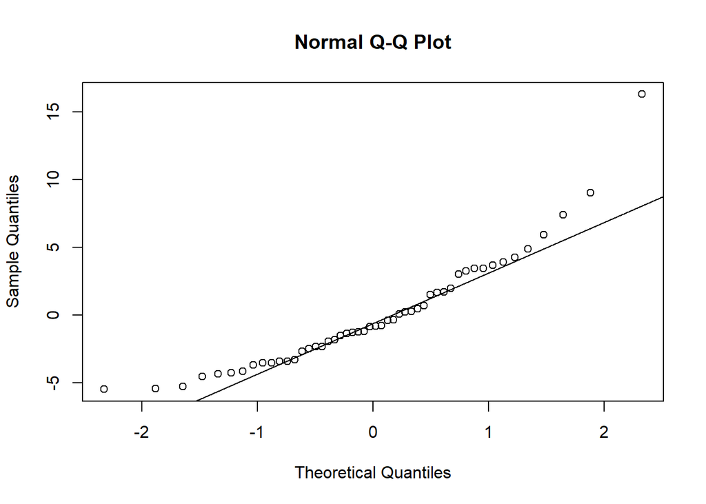

```r
qqnorm(quad$residuals)
qqline(quad$residuals)
```

# Part b

# Part c

```r
full=lm(price~ mileage+ age  + I(age^2) + I(mileage^2) + I(mileage*age),data=cardata)
simple=lm(price~mileage + age, data=cardata)

anova(simple, full)
```

```
## Analysis of Variance Table
##
## Model 1: price ~ mileage + age
## Model 2: price ~ mileage + age + I(age^2) + I(mileage^2) + I(mileage *
##     age)
##   Res.Df    RSS Df Sum of Sq      F  Pr(>F)
## 1     47 979.51
## 2     44 836.83  3    142.67 2.5006 0.07178 .
## ---
## Signif. codes:  0 '***' 0.001 '**' 0.01 '*' 0.05 '.' 0.1 ' ' 1
```

# Part d

```r
full=lm(price ~ mileage + I(mileage^2)  + I(mileage*age),data=cardata)

simple=lm(price~ age + I(age^2), data=cardata)

anova(simple, full)
```

```
## Analysis of Variance Table
##
## Model 1: price ~ age + I(age^2)
## Model 2: price ~ mileage + I(mileage^2) + I(mileage * age)
##   Res.Df     RSS Df Sum of Sq      F    Pr(>F)
## 1     47 1232.52
## 2     46  894.01  1    338.51 17.418 0.0001318 ***
## ---
## Signif. codes:  0 '***' 0.001 '**' 0.01 '*' 0.05 '.' 0.1 ' ' 1
```

The null hypothesis is that age is more important than mileage, whereas the alternative is mileage is more important. Our F statistic of 17.418 and corresponding p value of .0001 shows that the mileage terms improves the model.

# Wrap up

The model with the best adjusted R squared is our full model with 5 terms, with a adjusted r squared of .87. For simplicity, it may be best to use the simple model with just age and price in assignment 3, which has an adjusted r squared of .85. To really know which one is better we would need more data to check for overfitting.